# T de Student para una muestra

### Hipótesis:

$H_0: µ=µ_0$ ;La media de nuestra variable es igual a la media que hipotetizamos

$H_1: µ≠µ_0$ ;La media de nuestra variable es distinta a la media que hipotetizamos

### El estadístico T:

El estadístico T sirve para contrastar la igualdad de medias, este se distribuye con n-1 grados de libertad, siendo n la longitud de nuestra variable.

Este estadístico se define como:

$\LARGE T=\frac{\bar{X}-µ_0}{S/√n}≡t_{(n-1)}$

Siendo el valor de la desviación típica:

$\LARGE S=\sqrt{\frac{\sum_{i=1}^n (X_i-\bar{X})}{n-1}}$

$µ_0 =$ Media de hipotesis

$\bar{X} =$ Media de la variable

$n =$ Tamaño muestral

$t =$ t de Student

### Cálculo:

Suponiendo una variable aleatoria distribuida normalmente:

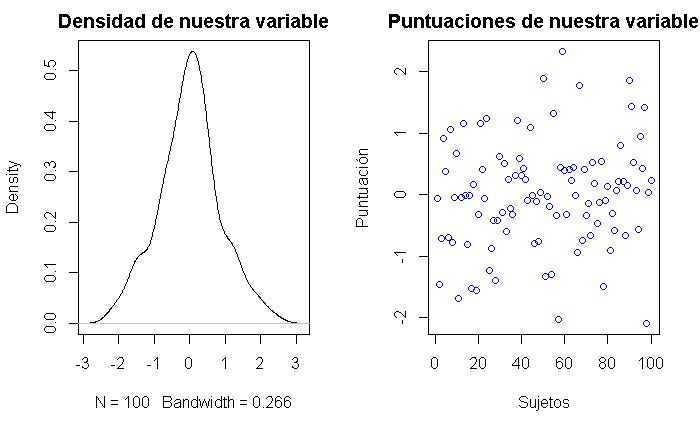

| p1 | p2 | p3 | p4 | p5 | p6 | p7 | p8 | p9 | p10 | p11 | p12 | p13 | p14 | p15 | p16 | p17 | p18 | p19 | p20 | p21 | p22 | p23 | p24 | p25 | p26 | p27 | p28 | p29 | p30 | … |
| --- | --- | --- | --- | --- | --- | --- | --- | --- | --- | --- | --- | --- | --- | --- | --- | --- | --- | --- | --- | --- | --- | --- | --- | --- | --- | --- | --- | --- | --- | --- |
| -0.06440033 | -1.467818 | -0.7212674 | 0.9124247 | 0.3816828 | -0.7021086 | 1.055415 | -0.7859864 | -0.03902174 | 0.6739724 | -1.697455 | -0.03920954 | 1.154329 | -0.01196403 | -0.8039375 | -0.01568838 | -1.527325 | 0.1693002 | -1.555898 | -0.3171784 | 1.157308 | 0.4065751 | -0.06347427 | 1.243008 | -1.241957 | -0.8717426 | -0.4282906 | -1.390244 | -0.425804 | 0.6214814 | … |

Calculamos el valor del estadístico previamente indicado $\large T=\frac{\bar{X}-µ_0}{S/√n}≡t_{(n-1)}$ en R, considerando “x” nuestra variable y Nu_0 = $µ_0$ mediante:

```r
Nu_0 <- 0

Estadistico <- (mean(x) - Nu_0)/(sd(x)/sqrt(length(x)))
Estadistico.redondeado <- round(Estadistico,2)
```

```
El valor del estadístico T es -0.12
```

Una vez tenemos el valor de T, buscamos en la tabla t de Student el valor de $t_{(n-1)}$, como el tamaño muestral es de 100, y el valor de alpha que queremos es de 0.05, buscamos en la tabla $t_{99,0.05}$

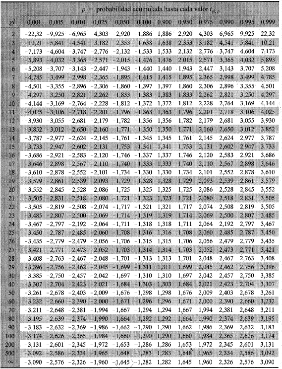

### Interpretación:

- En un contraste bilateral:

El valor que estamos buscando es $t_{99,0.05}=-1.6603912$

Como el valor de $t_{99,0.05}$ es **menor** que $T=-0.1173834$, aceptamos la hipótesis nula, concluyendo que no tenemos evidencia de diferencia significativa entre el valor de $µ_0$ y $µ$ para un nivel de significación de 0.05.

En R, el valor p de significación en un contraste bilateral se obtiene mediante

```r
2*pt(q = -abs(Estadistico), df=99)
```

```
[1] 0.9067941
```

- En un contraste unilateral izquierdo:

Como el valor de $t_{99,2*0.05}=-1.2901614$ es **menor** que $T=-0.1173834$, aceptamos la hipótesis nula, concluyendo que no tenemos evidencia de diferencia significativa de que el valor $µ_0$ sea menor que $µ$ para un nivel de significación de 0.05.

En R, el valor p de significación en un contraste unilateral izquierdo se obtiene mediante

```r
pt(q = Estadistico, df=99)
```

```
[1] 0.453397
```

- En un contraste unilateral derecho:

Como el valor de $t_{[99,1-(2*0.05)]}=1.2901614$ es **mayor** que $T=-0.1173834$, aceptamos la hipótesis nula, concluyendo que no tenemos evidencia de diferencia significativa de que el valor $µ_0$ sea mayor que $µ$ para un nivel de significación de 0.05.

En R, el valor p de significación en un contraste unilateral derecho se obtiene mediante

```r
1-pt(q = Estadistico, df=99)
```

```
[1] 0.546603
```